# Data Wrangling in R

Natalia Obukhova

May 21, 2019

Loading the library

Creating a tibble “~” for the column name

```r
data <- tribble(
  ~user, ~device, ~time, ~error,
  "P01", "Mouse", 15, 2,
  "P01", "Trackpad", 20, 5,
  "P02", "Mouse", 12, 3,
  "P02", "Trackpad", 17, 4
)
data
```

```
## # A tibble: 4 x 4
##   user  device    time error
##   <chr> <chr>    <dbl> <dbl>
## 1 P01   Mouse       15     2
## 2 P01   Trackpad    20     5
## 3 P02   Mouse       12     3
## 4 P02   Trackpad    17     4
```

# 1 Columns

## 1.1 Arranging

Arrange by a column name in the ascending order by using *arrange(c)*

```r
data %>%
  arrange(time)
```

```
## # A tibble: 4 x 4
##   user  device    time error
##   <chr> <chr>    <dbl> <dbl>
## 1 P02   Mouse       12     3
## 2 P01   Mouse       15     2
## 3 P02   Trackpad    17     4
## 4 P01   Trackpad    20     5
```

Arrange by several columns in the ascending order by using *arrange(c1, c2)*

```r
data %>%
  arrange(time, error)
```

```
## # A tibble: 4 x 4
##   user  device    time error
##   <chr> <chr>    <dbl> <dbl>
## 1 P02   Mouse       12     3
## 2 P01   Mouse       15     2
## 3 P02   Trackpad    17     4
## 4 P01   Trackpad    20     5
```

Arrange by a column name in the *descending order* by using arrange*(desc(c)*)

```r
data %>%
  arrange(desc(time))
```

```
## # A tibble: 4 x 4
##   user  device    time error
##   <chr> <chr>    <dbl> <dbl>
## 1 P01   Trackpad    20     5
## 2 P02   Trackpad    17     4
## 3 P01   Mouse       15     2
## 4 P02   Mouse       12     3
```

## 1.2 Selecting

Select only *some columns* by *select(c1, c2, ..)*

```r
data %>%
  select(user, device, time)
```

```
## # A tibble: 4 x 3
##   user  device    time
##   <chr> <chr>    <dbl>
## 1 P01   Mouse       15
## 2 P01   Trackpad    20
## 3 P02   Mouse       12
## 4 P02   Trackpad    17
```

Select *all the columns except for some* by *select(-c1, -c2,..)*

```r
data %>%
  select(-error)
```

```
## # A tibble: 4 x 3
##   user  device    time
##   <chr> <chr>    <dbl>
## 1 P01   Mouse       15
## 2 P01   Trackpad    20
## 3 P02   Mouse       12
## 4 P02   Trackpad    17
```

## 1.3 Reordering and renaming

*Reorder* the columns by *select(c1, everything())*

```r
data %>%
  select(device, everything())
```

```
## # A tibble: 4 x 4
##   device   user   time error
##   <chr>    <chr> <dbl> <dbl>
## 1 Mouse    P01      15     2
## 2 Trackpad P01      20     5
## 3 Mouse    P02      12     3
## 4 Trackpad P02      17     4
```

*Rename* the columns by *select(c1new=c1, c2new=c2, c3)*

```r
data %>%
  select(user, iv = device, dv_time = time, dv_error = error)
```

```
## # A tibble: 4 x 4
##   user  iv       dv_time dv_error
##   <chr> <chr>      <dbl>    <dbl>
## 1 P01   Mouse         15        2
## 2 P01   Trackpad      20        5
## 3 P02   Mouse         12        3
## 4 P02   Trackpad      17        4
```

## 1.4 Selecting by a pattern

Select all the columns which *names match the pattern* - given string in *any position*

```r
data %>%
  select(user, iv = device, dv_time = time, dv_error = error) %>%
  select(iv, matches("dv"))
```

```
## # A tibble: 4 x 3
##   iv       dv_time dv_error
##   <chr>      <dbl>    <dbl>
## 1 Mouse         15        2
## 2 Trackpad      20        5
## 3 Mouse         12        3
## 4 Trackpad      17        4
```

Select all the columns which *start with* something

```r
data %>%
  select(user, iv = device, dv_time = time, dv_error = error) %>%
  select(iv, starts_with("dv"))
```

```
## # A tibble: 4 x 3
##   iv       dv_time dv_error
##   <chr>      <dbl>    <dbl>
## 1 Mouse         15        2
## 2 Trackpad      20        5
## 3 Mouse         12        3
## 4 Trackpad      17        4
```

# 2 Rows

## 2.1 Any place

Select specific rows my *matching criterion* using *filter(c == “criterion”)*

```r
data %>%
  filter(device == "Mouse")
```

```
## # A tibble: 2 x 4
##   user  device  time error
##   <chr> <chr>  <dbl> <dbl>
## 1 P01   Mouse     15     2
## 2 P02   Mouse     12     3
```

## 2.2 And

Select specific rows my *matching and* using *filter(cond1 & cond2)*

```r
data %>%
  filter(device == "Mouse" & time > 13)
```

```
## # A tibble: 1 x 4
##   user  device  time error
##   <chr> <chr>  <dbl> <dbl>
## 1 P01   Mouse     15     2
```

## 2.3 Or

Select specific rows my *matching or* using *filter(cond1 | cond2)*

```r
data %>%
  filter(device == "Mouse" | time > 13)
```

```
## # A tibble: 4 x 4
##   user  device    time error
##   <chr> <chr>    <dbl> <dbl>
## 1 P01   Mouse       15     2
## 2 P01   Trackpad    20     5
## 3 P02   Mouse       12     3
## 4 P02   Trackpad    17     4
```

# 3 Combine columns

## 3.1 Unite (concatenate)

*Unite columns* by *unite(new_name, c1, c2, sep = “-”)* (can use more c). Default sep = “_"

```r
data %>%
  unite(user_device, user, device, sep = "-")
```

```
## # A tibble: 4 x 3
##   user_device   time error
##   <chr>        <dbl> <dbl>
## 1 P01-Mouse       15     2
## 2 P01-Trackpad    20     5
## 3 P02-Mouse       12     3
## 4 P02-Trackpad    17     4
```

## 3.2 Separate

*Separate columns* by *separate(cname, c(“c1”, “c2”))*. Default sep = “_"

```r
united_data <- data %>%
  unite(user_device, user, device, sep = "-")

united_data
```

```
## # A tibble: 4 x 3
##   user_device   time error
##   <chr>        <dbl> <dbl>
## 1 P01-Mouse       15     2
## 2 P01-Trackpad    20     5
## 3 P02-Mouse       12     3
## 4 P02-Trackpad    17     4
```

```r
united_data %>%
  separate(user_device, c("user", "device"), sep = "-")
```

```
## # A tibble: 4 x 4
##   user  device    time error
##   <chr> <chr>    <dbl> <dbl>
## 1 P01   Mouse       15     2
## 2 P01   Trackpad    20     5
## 3 P02   Mouse       12     3
## 4 P02   Trackpad    17     4
```

## 3.3 Bind columns into one table from 2 tables

Create two tibbles

```r
data_left <- tribble(
  ~user, ~device,
  "P01", "Mouse",
  "P01", "Trackpad",
  "P02", "Mouse",
  "P02", "Trackpad"
)

data_right <- tribble(
  ~time, ~error,
  15,     2,
  20,     5,
  12,     3,
  17,     4
)
```

## 3.4 Bind columns

*Bind columns (left and right)* by *bind_cols(table1, table2)* (can add more tables)

```r
bind_cols(data_left, data_right)
```

```
## # A tibble: 4 x 4
##   user  device    time error
##   <chr> <chr>    <dbl> <dbl>
## 1 P01   Mouse       15     2
## 2 P01   Trackpad    20     5
## 3 P02   Mouse       12     3
## 4 P02   Trackpad    17     4
```

## 3.5 Bind rows

*Bind rows (top and bottom)* by *bind_rows(table1, table2)*

```r
data_top <- tribble(
  ~user, ~device,      ~time, ~error,
  "P01", "Mouse",      15,     2,
  "P01", "Trackpad",   20,     5
)

data_bottom <- tribble(
   ~user, ~device,      ~time, ~error,
   "P02", "Mouse",      12,     3,
   "P02", "Trackpad",   17,     4
)

bind_rows(data_top, data_bottom)
```

```
## # A tibble: 4 x 4
##   user  device    time error
##   <chr> <chr>    <dbl> <dbl>
## 1 P01   Mouse       15     2
## 2 P01   Trackpad    20     5
## 3 P02   Mouse       12     3
## 4 P02   Trackpad    17     4
```

# 4 Joins

Two tibbles with data

```r
data_time <- tribble(
  ~user, ~device,      ~time,
   "P01", "Mouse",      15,
   "P01", "Trackpad",   20,
   "P02", "Mouse",      12
   #P02 trackpad is missing
)

data_error <- tribble(
  ~user, ~device,      ~error,
   "P01", "Mouse",      2,
   #P01 trackpad is missing
   "P02", "Mouse",      3,
   "P02", "Trackpad",   4
)
```

## 4.1 Inner join

*Inner join* will take the data from two tables and bind the data together by looking at the key *inner_join(table1, table2, by = c(c1, c2,..))*, where the rows exist in both tables. Here, it can’t combine P01 and P02 trackpad, because it is missing in one of the tables used for a join.

```r
inner_join(data_time, data_error, by = c("user", "device"))
```

```
## # A tibble: 2 x 4
##   user  device  time error
##   <chr> <chr>  <dbl> <dbl>
## 1 P01   Mouse     15     2
## 2 P02   Mouse     12     3
```

## 4.2 Full join

*Full join* will take all the data from the tables and replace the missing data with NA

```r
full_join(data_time, data_error, by = c("user", "device"))
```

```
## # A tibble: 4 x 4
##   user  device    time error
##   <chr> <chr>    <dbl> <dbl>
## 1 P01   Mouse       15     2
## 2 P01   Trackpad    20    NA
## 3 P02   Mouse       12     3
## 4 P02   Trackpad    NA     4
```

## 4.3 Left- and right join

*left_join* preserves NULL values only from the left table, *right_join* only from the right table

```r
left_join(data_time, data_error, by = c("user", "device"))
```

```
## # A tibble: 3 x 4
##   user  device    time error
##   <chr> <chr>    <dbl> <dbl>
## 1 P01   Mouse       15     2
## 2 P01   Trackpad    20    NA
## 3 P02   Mouse       12     3
```

```r
right_join(data_time, data_error, by = c("user", "device"))
```

```
## # A tibble: 3 x 4
##   user  device    time error
##   <chr> <chr>    <dbl> <dbl>
## 1 P01   Mouse       15     2
## 2 P02   Mouse       12     3
## 3 P02   Trackpad    NA     4
```

# 5 Set operations

Creating two tibbles

```r
data_set1 <- tribble(
  ~user, ~device,
  "P01", "Mouse",
  "P01", "Trackpad"
)

data_set2 <- tribble(
  ~user, ~device,
  "P01", "Trackpad", #same as the data_set1
  "P02", "Mouse",
  "P02", "Trackpad"
)
```

All elements from both tables - *union(set1, set2)*

```r
union(data_set1, data_set2)
```

```
## # A tibble: 4 x 2
##   user  device
##   <chr> <chr>
## 1 P02   Trackpad
## 2 P02   Mouse
## 3 P01   Trackpad
## 4 P01   Mouse
```

Elements, that are present in both tables - *intersect(set1, set2)*

```r
intersect(data_set1, data_set2)
```

```
## # A tibble: 1 x 2
##   user  device
##   <chr> <chr>
## 1 P01   Trackpad
```

# 6 Shaping the data

Prepare the data

```r
data <- data %>%
  select(user, device, time)
data
```

```
## # A tibble: 4 x 3
##   user  device    time
##   <chr> <chr>    <dbl>
## 1 P01   Mouse       15
## 2 P01   Trackpad    20
## 3 P02   Mouse       12
## 4 P02   Trackpad    17
```

## 6.1 Long to wide

Using *spread(column_to_spread_over_mult_columns, column_name_of_the_values_to_fill)*

```r
data_wide_device <-
  data %>%
  spread(device, time)
data_wide_device
```

```
## # A tibble: 2 x 3
##   user  Mouse Trackpad
##   <chr> <dbl>    <dbl>
## 1 P01      15       20
## 2 P02      12       17
```

## 6.2 Wide to long

Using *gather(name_of_the_new_column, column_values_to_cells, c1_name, c2_name)*

```r
data_wide_device %>%
  gather(device, time, Mouse, Trackpad)
```

```
## # A tibble: 4 x 3
##   user  device    time
##   <chr> <chr>    <dbl>
## 1 P01   Mouse       15
## 2 P02   Mouse       12
## 3 P01   Trackpad    20
## 4 P02   Trackpad    17
```

## 6.3 Combining spread and gather

First, gather the data (wide->long), then spread differently(long->wide)

```r
data_wide_device %>%
  gather(device, time, Mouse, Trackpad) %>%
  spread(user, time)
```

```
## # A tibble: 2 x 3
##   device     P01   P02
##   <chr>    <dbl> <dbl>
## 1 Mouse       15    12
## 2 Trackpad    20    17
```

# 7 Summarise the data

## 7.1 Deriving a new summary table by group

Data definition

```r
data <- tribble(
  ~user, ~device, ~time, ~error,
  "P01", "Mouse", 15, 2,
  "P01", "Trackpad", 20, 5,
  "P02", "Mouse", 12, 3,
  "P02", "Trackpad", 17, 4
)
```

2 steps: *group_by(col1)* over the column1 and then *summarize(col2 = aggr(col2), col3 = aggr(col3), ..)* Here aggr() can be: - mean(col) - mean of the values in the column - sum(col) - sum of the values in the column - n(col) - number of rows in the specified group

```r
data %>%
  group_by(device) %>%
  summarize(
    time = mean(time),
    error = sum(error),
    n = n())
```

```
## # A tibble: 2 x 4
##   device    time error     n
##   <chr>    <dbl> <dbl> <int>
## 1 Mouse     13.5     5     2
## 2 Trackpad  18.5     9     2
```

# 8 Mutating tables

## 8.1 Change the values

Here - substract 5 for each time value by *mutate(col1 = col1 - 5)*

```r
data %>%
  mutate(time = time - 5)
```

```
## # A tibble: 4 x 4
##   user  device    time error
##   <chr> <chr>    <dbl> <dbl>
## 1 P01   Mouse       10     2
## 2 P01   Trackpad    15     5
## 3 P02   Mouse        7     3
## 4 P02   Trackpad    12     4
```

## 8.2 Add new column

E.g. add new column trial equal to row number

```r
data %>%
  mutate(trial = row_number())
```

```
## # A tibble: 4 x 5
##   user  device    time error trial
##   <chr> <chr>    <dbl> <dbl> <int>
## 1 P01   Mouse       15     2     1
## 2 P01   Trackpad    20     5     2
## 3 P02   Mouse       12     3     3
## 4 P02   Trackpad    17     4     4
```

Order of the condition

```r
data %>%
  mutate(trial = row_number()) %>%
  group_by(user) %>% #here we have two tables
  mutate(order = row_number()) %>%
  ungroup() #here we combine them
```

```
## # A tibble: 4 x 6
##   user  device    time error trial order
##   <chr> <chr>    <dbl> <dbl> <int> <int>
## 1 P01   Mouse       15     2     1     1
## 2 P01   Trackpad    20     5     2     2
## 3 P02   Mouse       12     3     3     1
## 4 P02   Trackpad    17     4     4     2
```

# 9 Strings

## 9.1 Substring

Substract part of the string in the column. Here we substract the part of the string starting with the position 2 (str[1]=P)

```r
data %>%
  mutate(user = str_sub(user, start = 2))
```

```
## # A tibble: 4 x 4
##   user  device    time error
##   <chr> <chr>    <dbl> <dbl>
## 1 01    Mouse       15     2
## 2 01    Trackpad    20     5
## 3 02    Mouse       12     3
## 4 02    Trackpad    17     4
```

Then, we can change the type of the column:

```r
data %>%
  mutate(user = as.numeric(str_sub(user, start = 2)))
```

```
## # A tibble: 4 x 4
##    user device    time error
##   <dbl> <chr>    <dbl> <dbl>
## 1     1 Mouse       15     2
## 2     1 Trackpad    20     5
## 3     2 Mouse       12     3
## 4     2 Trackpad    17     4
```

## 9.2 Case changing

To lower

```r
data %>%
  mutate(device = tolower(device))
```

```
## # A tibble: 4 x 4
##   user  device    time error
##   <chr> <chr>    <dbl> <dbl>
## 1 P01   mouse       15     2
## 2 P01   trackpad    20     5
## 3 P02   mouse       12     3
## 4 P02   trackpad    17     4
```

To upper

```r
data %>%
  mutate(device = toupper(device))
```

```
## # A tibble: 4 x 4
##   user  device    time error
##   <chr> <chr>    <dbl> <dbl>
## 1 P01   MOUSE       15     2
## 2 P01   TRACKPAD    20     5
## 3 P02   MOUSE       12     3
## 4 P02   TRACKPAD    17     4
```

## 9.3 Replacing parts

Replace the part of the pattern in the string to be replaced with another pattern specified: *str_replace(col, pattern_old, pattern_new)*

```r
data %>%
  mutate(device = str_replace(device, "pad", "Pad"))
```

```
## # A tibble: 4 x 4
##   user  device    time error
##   <chr> <chr>    <dbl> <dbl>
## 1 P01   Mouse       15     2
## 2 P01   TrackPad    20     5
## 3 P02   Mouse       12     3
## 4 P02   TrackPad    17     4
```

New tibble:

```r
data <- tribble(
  ~user, ~device,        ~time, ~error,
  "P01", "Mouse",          15, 2,
  "P01", "LargeTrackpad",  20, 5,
  "P02", "Mouse",          12, 3,
  "P02", "SmallTrackpad",  17, 4
)
```

But we want all the trackpads to be the same, so: *.+* any characters one or more time before the Trackpad

```r
data %>%
  mutate(device = str_replace(device, ".+Trackpad", "Trackpad"))
```

```
## # A tibble: 4 x 4
##   user  device    time error
##   <chr> <chr>    <dbl> <dbl>
## 1 P01   Mouse       15     2
## 2 P01   Trackpad    20     5
## 3 P02   Mouse       12     3
## 4 P02   Trackpad    17     4
```

## 9.4 Detect the strings

Here we choose strings by the pattern: *str_detect(string, pattern)*

```r
data %>%
  filter(str_detect(device, ".+Trackpad"))
```

```
## # A tibble: 2 x 4
##   user  device         time error
##   <chr> <chr>         <dbl> <dbl>
## 1 P01   LargeTrackpad    20     5
## 2 P02   SmallTrackpad    17     4
```

# 10 Durations

New tibble, time in seconds:

```r
data <- tribble(
  ~user, ~device,        ~time,
  "P01", "Mouse",          80,
  "P01", "LargeTrackpad",  70,
  "P02", "Mouse",          120,
  "P02", "SmallTrackpad",  115
)
```

Importing functions from the package *lubridate*

Creating columns with minutes, seconds and periods

```r
data %>%
  mutate(
    period = seconds_to_period(time),
    minutes = minute(period), #extract mins
    seconds = second(period) #extract secs
  )
```

```
## # A tibble: 4 x 6
##   user  device         time period       minutes seconds
##   <chr> <chr>         <dbl> <S4: Period>   <dbl>   <dbl>
## 1 P01   Mouse            80 1M 20S             1      20
## 2 P01   LargeTrackpad    70 1M 10S             1      10
## 3 P02   Mouse           120 2M 0S              2       0
## 4 P02   SmallTrackpad   115 1M 55S             1      55
```

# 11 Factors

Data definition

```r
data <- tribble(
  ~user, ~device,   ~time, ~error,
  "P01", "Mouse",    15,    2,
  "P01", "Trackpad", 20,    5,
  "P02", "Mouse",    12,    3,
  "P02", "Trackpad", 17,    4
)
```

Plotting the data:

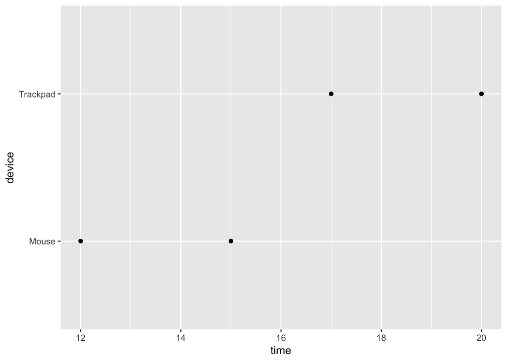

```r
data %>%
  ggplot(aes(x = device, y = time)) +
  geom_point() +
  coord_flip()
```

Suppose we want to swap the order in y by specifying the level of the factor. We can use *factor(col, levels = c(“”,“”,..))*

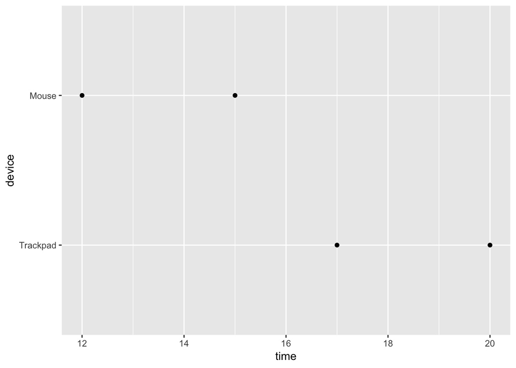

```r
data %>%
  mutate(device = factor(device, levels = c("Trackpad", "Mouse"))) %>%
  ggplot(aes(x = device, y = time)) +
  geom_point() +
  coord_flip() #order in reverse
```

OR *fct_rev()*

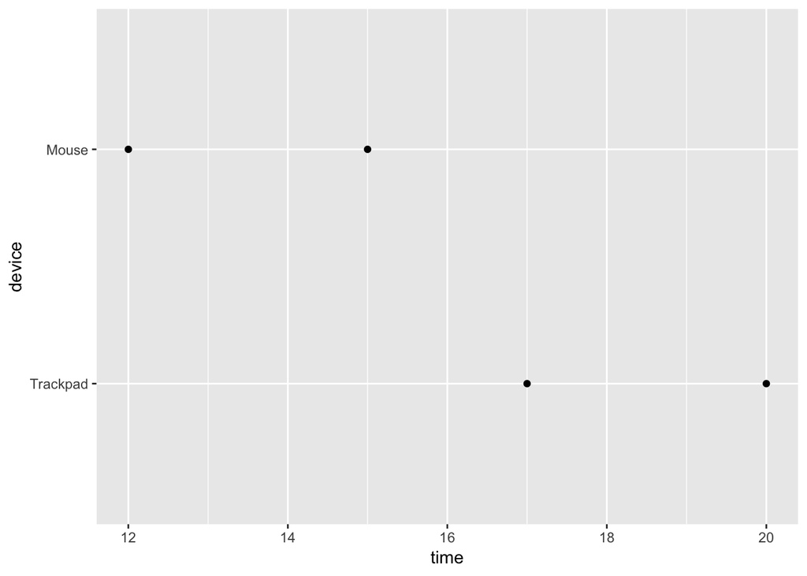

```r
data %>%
  mutate(device = fct_rev(factor(device))) %>% #reverse the order
  ggplot(aes(x = device, y = time)) +
  geom_point() +
  coord_flip() #order in reverse
```

# 12 Conditions

Example: Classify the error into types by *if_else(condition, true_value, false_value)*

```r
data %>%
  mutate(error_category = if_else(error < 3, "low", "high"))
```

```
## # A tibble: 4 x 5
##   user  device    time error error_category
##   <chr> <chr>    <dbl> <dbl> <chr>
## 1 P01   Mouse       15     2 low
## 2 P01   Trackpad    20     5 high
## 3 P02   Mouse       12     3 high
## 4 P02   Trackpad    17     4 high
```

If more than 2 values in conditions, then we can use *case_when()*. Evaluates from top to bottom.

```r
data %>%
  mutate(time_category = case_when(
    time < 13              ~ "fast",
    between(time, 13, 17)  ~ "medium",
    TRUE                   ~ "slow"      #everything else that haven't been caught
  ))
```

```
## # A tibble: 4 x 5
##   user  device    time error time_category
##   <chr> <chr>    <dbl> <dbl> <chr>
## 1 P01   Mouse       15     2 medium
## 2 P01   Trackpad    20     5 slow
## 3 P02   Mouse       12     3 fast
## 4 P02   Trackpad    17     4 medium
```